# Binary-Classification_Log-Reg

## Logistic Regression for Binary classification

#### Loading the required libraries

```python
import pandas as pd
import numpy as np

from sklearn.model_selection import train_test_split
from sklearn.metrics import confusion_matrix, roc_curve, auc
from sklearn.linear_model import LogisticRegression

import matplotlib.pyplot as plt
```

#### Problem

```
Is to identify products at risk of backorder before the event occurs so the business has time to react.
```

#### Data

Data file contains the historical data for the 8 weeks prior to the week we are trying to predict. The data was taken as weekly snapshots at the start of each week. Columns are defined as follows:

```
sku - Random ID for the product

national_inv - Current inventory level for the part

lead_time - Transit time for product (if available)

in_transit_qty - Amount of product in transit from source

forecast_3_month - Forecast sales for the next 3 months

forecast_6_month - Forecast sales for the next 6 months

forecast_9_month - Forecast sales for the next 9 months

sales_1_month - Sales quantity for the prior 1 month time period

sales_3_month - Sales quantity for the prior 3 month time period

sales_6_month - Sales quantity for the prior 6 month time period

sales_9_month - Sales quantity for the prior 9 month time period

min_bank - Minimum recommend amount to stock

potential_issue - Source issue for part identified

pieces_past_due - Parts overdue from source

perf_6_month_avg - Source performance for prior 6 month period

perf_12_month_avg - Source performance for prior 12 month period

local_bo_qty - Amount of stock orders overdue

deck_risk - Part risk flag

oe_constraint - Part risk flag

ppap_risk - Part risk flag

stop_auto_buy - Part risk flag

rev_stop - Part risk flag

went_on_backorder - Product actually went on backorder. This is the target value.

     Yes or 1 : Product backordered

     No or 0  : Product not backordered
```

#### Identify Right Error Metrics

```
Based on the businees have to identify right error metrics.
```

#### Loading the data

```python
data = pd.read_csv("BackOrders.csv",header=0)
```

#### Understand the Data

See the No. row and columns

```python
data.shape
```

```
(61589, 23)
```

Display the columns

```python
data.columns
```

```
Index(['sku', 'national_inv', 'lead_time', 'in_transit_qty',
       'forecast_3_month', 'forecast_6_month', 'forecast_9_month',
       'sales_1_month', 'sales_3_month', 'sales_6_month', 'sales_9_month',
       'min_bank', 'potential_issue', 'pieces_past_due', 'perf_6_month_avg',
       'perf_12_month_avg', 'local_bo_qty', 'deck_risk', 'oe_constraint',
       'ppap_risk', 'stop_auto_buy', 'rev_stop', 'went_on_backorder'],
      dtype='object')
```

Display the index

```python
data.index
```

```
RangeIndex(start=0, stop=61589, step=1)
```

See the top rows of the data

```python
data[:3]
```

|  | sku | national_inv | lead_time | in_transit_qty | forecast_3_month | forecast_6_month | forecast_9_month | sales_1_month | sales_3_month | sales_6_month | ... | pieces_past_due | perf_6_month_avg | perf_12_month_avg | local_bo_qty | deck_risk | oe_constraint | ppap_risk | stop_auto_buy | rev_stop | went_on_backorder |
| --- | --- | --- | --- | --- | --- | --- | --- | --- | --- | --- | --- | --- | --- | --- | --- | --- | --- | --- | --- | --- | --- |
| 0 | 1888279 | 117 | NaN | 0 | 0 | 0 | 0 | 0 | 0 | 15 | ... | 0 | -99.00 | -99.00 | 0 | No | No | Yes | Yes | No | No |
| 1 | 1870557 | 7 | 2.0 | 0 | 0 | 0 | 0 | 0 | 0 | 0 | ... | 0 | 0.50 | 0.28 | 0 | Yes | No | No | Yes | No | No |
| 2 | 1475481 | 258 | 15.0 | 10 | 10 | 77 | 184 | 46 | 132 | 256 | ... | 0 | 0.54 | 0.70 | 0 | No | No | No | Yes | No | No |

3 rows × 23 columns

Shows a quick statistic summary of your data using describe

```python
data.describe(include='all')
```

|  | sku | national_inv | lead_time | in_transit_qty | forecast_3_month | forecast_6_month | forecast_9_month | sales_1_month | sales_3_month | sales_6_month | ... | pieces_past_due | perf_6_month_avg | perf_12_month_avg | local_bo_qty | deck_risk | oe_constraint | ppap_risk | stop_auto_buy | rev_stop | went_on_backorder |
| --- | --- | --- | --- | --- | --- | --- | --- | --- | --- | --- | --- | --- | --- | --- | --- | --- | --- | --- | --- | --- | --- |
| count | 6.158900e+04 | 61589.000000 | 58186.000000 | 61589.000000 | 6.158900e+04 | 6.158900e+04 | 6.158900e+04 | 61589.000000 | 61589.000000 | 6.158900e+04 | ... | 61589.000000 | 61589.000000 | 61589.000000 | 61589.000000 | 61589 | 61589 | 61589 | 61589 | 61589 | 61589 |
| unique | NaN | NaN | NaN | NaN | NaN | NaN | NaN | NaN | NaN | NaN | ... | NaN | NaN | NaN | NaN | 2 | 2 | 2 | 2 | 2 | 2 |
| top | NaN | NaN | NaN | NaN | NaN | NaN | NaN | NaN | NaN | NaN | ... | NaN | NaN | NaN | NaN | No | No | No | Yes | No | No |
| freq | NaN | NaN | NaN | NaN | NaN | NaN | NaN | NaN | NaN | NaN | ... | NaN | NaN | NaN | NaN | 48145 | 61577 | 53792 | 59303 | 61569 | 50296 |
| mean | 2.037188e+06 | 287.721882 | 7.559619 | 30.192843 | 1.692728e+02 | 3.150413e+02 | 4.535760e+02 | 44.742957 | 150.732631 | 2.835465e+02 | ... | 1.605400 | -6.264182 | -5.863664 | 1.205361 | NaN | NaN | NaN | NaN | NaN | NaN |
| std | 6.564178e+05 | 4233.906931 | 6.498952 | 792.869253 | 5.286742e+03 | 9.774362e+03 | 1.420201e+04 | 1373.805831 | 5224.959649 | 8.872270e+03 | ... | 42.309229 | 25.537906 | 24.844514 | 29.981155 | NaN | NaN | NaN | NaN | NaN | NaN |
| min | 1.068628e+06 | -2999.000000 | 0.000000 | 0.000000 | 0.000000e+00 | 0.000000e+00 | 0.000000e+00 | 0.000000 | 0.000000 | 0.000000e+00 | ... | 0.000000 | -99.000000 | -99.000000 | 0.000000 | NaN | NaN | NaN | NaN | NaN | NaN |
| 25% | 1.498574e+06 | 3.000000 | 4.000000 | 0.000000 | 0.000000e+00 | 0.000000e+00 | 0.000000e+00 | 0.000000 | 0.000000 | 0.000000e+00 | ... | 0.000000 | 0.620000 | 0.640000 | 0.000000 | NaN | NaN | NaN | NaN | NaN | NaN |
| 50% | 1.898033e+06 | 10.000000 | 8.000000 | 0.000000 | 0.000000e+00 | 0.000000e+00 | 0.000000e+00 | 0.000000 | 2.000000 | 4.000000e+00 | ... | 0.000000 | 0.820000 | 0.800000 | 0.000000 | NaN | NaN | NaN | NaN | NaN | NaN |
| 75% | 2.314826e+06 | 57.000000 | 8.000000 | 0.000000 | 1.200000e+01 | 2.500000e+01 | 3.600000e+01 | 6.000000 | 17.000000 | 3.400000e+01 | ... | 0.000000 | 0.960000 | 0.950000 | 0.000000 | NaN | NaN | NaN | NaN | NaN | NaN |
| max | 3.284895e+06 | 673445.000000 | 52.000000 | 170976.000000 | 1.126656e+06 | 2.094336e+06 | 3.062016e+06 | 295197.000000 | 934593.000000 | 1.799099e+06 | ... | 7392.000000 | 1.000000 | 1.000000 | 2999.000000 | NaN | NaN | NaN | NaN | NaN | NaN |

11 rows × 23 columns

Display data type of each variable

```python
data.dtypes
```

```
sku                    int64
national_inv           int64
lead_time            float64
in_transit_qty         int64
forecast_3_month       int64
forecast_6_month       int64
forecast_9_month       int64
sales_1_month          int64
sales_3_month          int64
sales_6_month          int64
sales_9_month          int64
min_bank               int64
potential_issue       object
pieces_past_due        int64
perf_6_month_avg     float64
perf_12_month_avg    float64
local_bo_qty           int64
deck_risk             object
oe_constraint         object
ppap_risk             object
stop_auto_buy         object
rev_stop              object
went_on_backorder     object
dtype: object
```

#### Observations

```
sku is Categorical but is interpreted as int64
potential_issue, deck_risk, oe_constraint, ppap_risk, stop_auto_buy, rev_stop, and went_on_backorder are also categorical but is interpreted as object.
```

#### Convert all the attributes to appropriate type

Data type conversion

```
Using astype('category') to convert potential_issue, deck_risk, oe_constraint, ppap_risk, stop_auto_buy, rev_stop, and went_on_backorder attributes to categorical attributes.
```

```python
for col in ['sku', 'potential_issue', 'deck_risk', 'oe_constraint', 'ppap_risk', 'stop_auto_buy', 'rev_stop', 'went_on_backorder']:
    data[col] = data[col].astype('category')
```

Display data type of each variable

```python
data.dtypes
```

```
sku                  category
national_inv            int64
lead_time             float64
in_transit_qty          int64
forecast_3_month        int64
forecast_6_month        int64
forecast_9_month        int64
sales_1_month           int64
sales_3_month           int64
sales_6_month           int64
sales_9_month           int64
min_bank                int64
potential_issue      category
pieces_past_due         int64
perf_6_month_avg      float64
perf_12_month_avg     float64
local_bo_qty            int64
deck_risk            category
oe_constraint        category
ppap_risk            category
stop_auto_buy        category
rev_stop             category
went_on_backorder    category
dtype: object
```

#### Delete sku attribute

```python
np.size(np.unique(data.sku, return_counts=True)[0])
```

```
61589
```

```python
data.drop('sku', axis=1, inplace=True)
```

#### Missing Data

```
Missing value analysis and dropping the records with missing values
```

```python
data.isnull().sum()
```

```
national_inv            0
lead_time            3403
in_transit_qty          0
forecast_3_month        0
forecast_6_month        0
forecast_9_month        0
sales_1_month           0
sales_3_month           0
sales_6_month           0
sales_9_month           0
min_bank                0
potential_issue         0
pieces_past_due         0
perf_6_month_avg        0
perf_12_month_avg       0
local_bo_qty            0
deck_risk               0
oe_constraint           0
ppap_risk               0
stop_auto_buy           0
rev_stop                0
went_on_backorder       0
dtype: int64
```

Observing the number of records before and after missing value records removal

```python
print (data.shape)
```

```
(61589, 22)
```

```python
#Since the number of missing values is about 5%. For initial analysis we ignore all these records
data = data.dropna(axis=0)
```

```python
print(data.isnull().sum())
print(data.shape)
```

```
national_inv         0
lead_time            0
in_transit_qty       0
forecast_3_month     0
forecast_6_month     0
forecast_9_month     0
sales_1_month        0
sales_3_month        0
sales_6_month        0
sales_9_month        0
min_bank             0
potential_issue      0
pieces_past_due      0
perf_6_month_avg     0
perf_12_month_avg    0
local_bo_qty         0
deck_risk            0
oe_constraint        0
ppap_risk            0
stop_auto_buy        0
rev_stop             0
went_on_backorder    0
dtype: int64
(58186, 22)
```

#### Converting Categorical to Numeric

For some of the models all the independent attribute should be of type numeric and Linear Regression model is one among them. But this data set has some categorial attributes.

'pandas.get_dummies' To convert convert categorical variable into dummy/indicator variables

```python
print (data.columns)
```

```
Index(['national_inv', 'lead_time', 'in_transit_qty', 'forecast_3_month',
       'forecast_6_month', 'forecast_9_month', 'sales_1_month',
       'sales_3_month', 'sales_6_month', 'sales_9_month', 'min_bank',
       'potential_issue', 'pieces_past_due', 'perf_6_month_avg',
       'perf_12_month_avg', 'local_bo_qty', 'deck_risk', 'oe_constraint',
       'ppap_risk', 'stop_auto_buy', 'rev_stop', 'went_on_backorder'],
      dtype='object')
```

Creating dummy variables.

```
If we have k levels in a category, then we create k-1 dummy variables as the last one would be redundant. So we use the parameter drop_first in pd.get_dummies function that drops the first level in each of the category
```

```python
categorical_Attributes = data.select_dtypes(include=['category']).columns
```

```python
data = pd.get_dummies(columns=categorical_Attributes, data=data, prefix=categorical_Attributes, prefix_sep="_", drop_first=True)
```

```python
print (data.columns, data.shape)
```

```
Index(['national_inv', 'lead_time', 'in_transit_qty', 'forecast_3_month',
       'forecast_6_month', 'forecast_9_month', 'sales_1_month',
       'sales_3_month', 'sales_6_month', 'sales_9_month', 'min_bank',
       'pieces_past_due', 'perf_6_month_avg', 'perf_12_month_avg',
       'local_bo_qty', 'potential_issue_Yes', 'deck_risk_Yes',
       'oe_constraint_Yes', 'ppap_risk_Yes', 'stop_auto_buy_Yes',
       'rev_stop_Yes', 'went_on_backorder_Yes'],
      dtype='object') (58186, 22)
```

#### Target attribute distribution

```python
pd.value_counts(data['went_on_backorder_Yes'].values)
```

```
0    47217
1    10969
dtype: int64
```

#### Split the data in to train and test

sklearn.model_selection.train_test_split

```
Split arrays or matrices into random train and test subsets
```

```python
#Performing train test split on the data
X, y = data.loc[:,data.columns!='went_on_backorder_Yes'].values, data.loc[:,'went_on_backorder_Yes'].values

X_train, X_test, y_train, y_test = train_test_split(X, y, test_size=0.3, random_state=123)
```

```python
#To get the distribution in the target in train and test
print(pd.value_counts(y_train))
print(pd.value_counts(y_test))
```

```
0    33067
1     7663
dtype: int64
0    14150
1     3306
dtype: int64
```

#### Logistic Regression

```python
log_mod = LogisticRegression(random_state=123)
```

```python
model = log_mod.fit(X_train, y_train)
```

#### Predictions

```python
test_pred=model.predict(X_test)
train_pred=model.predict(X_train)
```

#### Getting evaluation metrics and evaluating model performance

```python
confusion_matrix_test = confusion_matrix(y_test, test_pred)
confusion_matrix_train = confusion_matrix(y_train, train_pred)

print(confusion_matrix_train)
print(confusion_matrix_test)
```

```
[[32796   271]
 [ 6360  1303]]
[[14037   113]
 [ 2784   522]]
```

#### Calculate Accuracy, True Positive Rate and True Negative Rates

```python
Accuracy_Train=(confusion_matrix_train[0,0]+confusion_matrix_train[1,1])/(confusion_matrix_train[0,0]+confusion_matrix_train[0,1]+confusion_matrix_train[1,0]+confusion_matrix_train[1,1])
TNR_Train= confusion_matrix_train[0,0]/(confusion_matrix_train[0,0]+confusion_matrix_train[0,1])
TPR_Train= confusion_matrix_train[1,1]/(confusion_matrix_train[1,0]+confusion_matrix_train[1,1])

print("Train TNR: ",TNR_Train)
print("Train TPR: ",TPR_Train)
print("Train Accuracy: ",Accuracy_Train)
```

```
Train TNR:  0.9918045180996159
Train TPR:  0.17003784418634998
Train Accuracy:  0.8371961698993371
```

```python
Accuracy_Test=(confusion_matrix_test[0,0]+confusion_matrix_test[1,1])/(confusion_matrix_test[0,0]+confusion_matrix_test[0,1]+confusion_matrix_test[1,0]+confusion_matrix_test[1,1])
TNR_Test= confusion_matrix_test[0,0]/(confusion_matrix_test[0,0] +confusion_matrix_test[0,1])
TPR_Test= confusion_matrix_test[1,1]/(confusion_matrix_test[1,0] +confusion_matrix_test[1,1])

print("Test TNR: ",TNR_Test)
print("Test TPR: ",TPR_Test)
print("Test Accuracy: ",Accuracy_Test)
```

```
Test TNR:  0.9920141342756184
Test TPR:  0.15789473684210525
Test Accuracy:  0.8340398716773603
```

#### Model -2 Logistic Regression with class weights balanced

As we have observed that the TPR for class 1 is pretty low and the model is biased towards majority class, lets see if class_weights have any influence in predictions

```python
log_mod = LogisticRegression(class_weight='balanced', max_iter=250, random_state=123)
```

```python
model = log_mod.fit(X_train, y_train)
```

#### Predictions

```python
test_pred=model.predict(X_test)
train_pred=model.predict(X_train)
```

#### Getting evaluation metrics and evaluating model performance

```python
confusion_matrix_test = confusion_matrix(y_test, test_pred)
confusion_matrix_train = confusion_matrix(y_train, train_pred)

print(confusion_matrix_train)
print(confusion_matrix_test)
```

```
[[18672 14395]
 [ 1054  6609]]
[[7844 6306]
 [ 475 2831]]
```

#### Calculate Accuracy, True Positive Rate and True Negative Rates

```python
Accuracy_Train=(confusion_matrix_train[0,0]+confusion_matrix_train[1,1])/(confusion_matrix_train[0,0]+confusion_matrix_train[0,1]+confusion_matrix_train[1,0]+confusion_matrix_train[1,1])
TNR_Train= confusion_matrix_train[0,0]/(confusion_matrix_train[0,0]+confusion_matrix_train[0,1])
TPR_Train= confusion_matrix_train[1,1]/(confusion_matrix_train[1,0]+confusion_matrix_train[1,1])

print("Train TNR: ",TNR_Train)
print("Train TPR: ",TPR_Train)
print("Train Accuracy: ",Accuracy_Train)
```

```
Train TNR:  0.5646717270995252
Train TPR:  0.8624559571969203
Train Accuracy:  0.6206972747360667
```

```python
Accuracy_Test=(confusion_matrix_test[0,0]+confusion_matrix_test[1,1])/(confusion_matrix_test[0,0]+confusion_matrix_test[0,1]+confusion_matrix_test[1,0]+confusion_matrix_test[1,1])
TNR_Test= confusion_matrix_test[0,0]/(confusion_matrix_test[0,0] +confusion_matrix_test[0,1])
TPR_Test= confusion_matrix_test[1,1]/(confusion_matrix_test[1,0] +confusion_matrix_test[1,1])

print("Test TNR: ",TNR_Test)
print("Test TPR: ",TPR_Test)
print("Test Accuracy: ",Accuracy_Test)
```

```
Test TNR:  0.5543462897526502
Test TPR:  0.8563218390804598
Test Accuracy:  0.6115375802016498
```

#### Plotting ROC curve to modify the threshold if necessary

1. Initially we have predicted the classes. This was easy because, by default the threshold was fixed at 0.5. Hence the probabilities got converted to 0 or 1 based on probability for that record
2. Now the values of 0's and 1's itself are not sufficient to get the ROC curve. We need to have the probabilities.
3. We have a function called predict_proba that generates probalility for success which can be used for plotting ROC

```python
train_pred_prob=model.predict_proba(X_train)
```

```python
print (train_pred_prob)
```

```
[[0.93560169 0.06439831]
 [0.44648968 0.55351032]
 [0.42577674 0.57422326]
 ...
 [0.38206819 0.61793181]
 [0.40299121 0.59700879]
 [0.54083924 0.45916076]]
```

```python
train_pred_prob  = train_pred_prob[:,1]
```

#### Getting ROC curve to adjust the threshold

```python
fpr, tpr, thresholds = roc_curve(y_train, train_pred_prob)
roc_auc = auc(fpr, tpr)
```

#### Using matplotlib for plotting the ROC curve

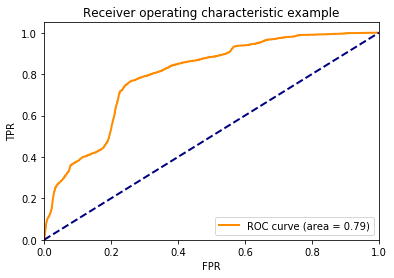

```python
plt.figure()
lw = 2
plt.plot(fpr,tpr, color='darkorange',
         lw=lw, label='ROC curve (area = %0.2f)' % roc_auc)
plt.plot([0, 1], [0, 1], color='navy', lw=lw, linestyle='--')
plt.xlim([0.0, 1.0])
plt.ylim([0.0, 1.05])
plt.xlabel('FPR')
plt.ylabel('TPR')
plt.title('Receiver operating characteristic example')
plt.legend(loc="lower right")
plt.show()
```

```python
X = pd.DataFrame({'TPR':tpr,'TNR': 1-fpr, 'Threshold':thresholds})
pd.set_option('display.max_rows', 11000)
X
```

[output not shown]

[output cut: 10435 more lines]